# Boruta-Dim-Redux

MCC

8/30/2019

Libraries

```r
library(knitr)
opts_chunk$set(cache = TRUE, warning = FALSE, message = FALSE, cache.lazy = FALSE)

Libraries = c("doMC", "knitr", "Boruta", "readr")

for(p in Libraries){  # Install if not present
    if(!require(p, character.only = TRUE)) { install.packages(p, dependencies = T) }
    library(p, character.only = TRUE)
}
```

Import data

```r
cancer_human_comps <- read_csv("../1data/cancer_human_comps.csv",
                               col_types = cols(Class = col_factor(levels = c("0","1")),
                                                PID = col_character()))
#View(cancer_human_comps)

colnames(cancer_human_comps)[244] <- "NA"
```

```r
cancer_human_Active <- cancer_human_comps[, c(1, 4:423)]

registerDoMC(cores = 3) # Start multi-processor mode
start_time <- Sys.time() # Start timer

set.seed(1000)
Boruta_cancer_human_Active <- Boruta(Class ~ ., data = cancer_human_Active, doTrace = 1, mtry = 2, ntree = 500)

registerDoSEQ() # Stop multi-processor mode
Sys.time() - start_time  # Display       time difference
```

```
## Time difference of 26.16059 mins
```

Show Model Info

```r
Boruta_cancer_human_Active
```

```
## Boruta performed 99 iterations in 26.15977 mins.
##  142 attributes confirmed important: `NA`, A, AA, AD, AE and 137
## more;
##  172 attributes confirmed unimportant: AC, AK, AN, AS, CM and 167
## more;
##  106 tentative attributes left: AH, AQ, AW, CD, CH and 101 more;
```

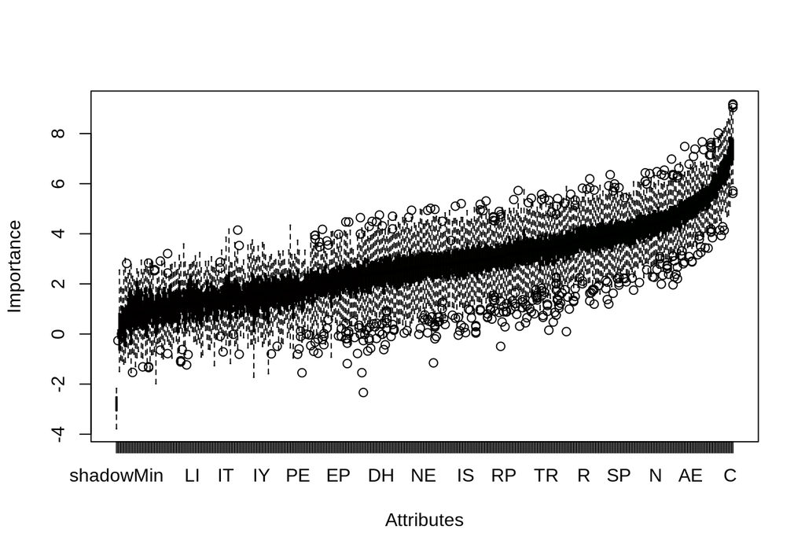

```r
plot(Boruta_cancer_human_Active)
```

Get Formula

```r
getConfirmedFormula(Boruta_cancer_human_Active)
```

```
## Class ~ A + C + D + E + F + G + H + K + L + N + Q + R + S + T +
##     V + Y + AA + AD + AE + AF + AG + AI + AL + AM + AP + AR +
##     AT + AV + AY + CA + CC + CE + CF + CG + CI + CK + CL + CN +
##     CP + CQ + CR + CS + CV + CY + DA + DC + DD + DG + DK + DP +
##     DQ + DR + DS + DW + EA + EC + EE + EK + EN + ES + FA + FC +
##     FK + FL + FT + GA + GC + GD + GG + GL + GR + GT + GV + HC +
##     HK + HS + IA + ID + IG + KC + KD + KE + KF + KH + KK + KN +
##     KQ + KR + KS + KY + LA + LC + LE + LH + LL + LQ + LS + ME +
##     `NA` + NC + NI + NK + NS + PA + PC + PD + PS + PT + PV +
##     QC + QE + QK + QL + RA + RD + RE + RI + RK + RM + SA + SC +
##     SE + SK + SL + SP + SQ + SS + ST + TA + TC + TD + TG + TK +
##     TS + TT + TV + VA + VC + YA + YC + YF + YL
## <environment: 0x56220f659ac0>
```

Results from **Boruta_cancer_human_Active**

- Class ~ A + C + D + E + F + G + H + K + L + N + #10 Q + R + S + T + V + Y + AA + AD + AE + AF + AG + AI + AL + AM + AP + AR + AT + AV + AY + CA + CC + CE + CF + CG + CI + CK + CL + CN + CP + CQ + CR + CS + CV + CY + DA + DC + DD + DG + DK + DP + #50 DQ + DR + DS + DW + EA + EC + EE + EK + EN + ES +  
  FA + FC + FK + FL + FT + GA + GC + GD + GG + GL +  
  GR + GT + GV + HC + HK + HS + IA + ID + IG + KC +  
  KD + KE + KF + KH + KK + KN + KQ + KR + KS + KY +  
  LA + LC + LE + LH + LL + LQ + LS + ME + `NA` + NC + #100 NI + NK + NS + PA + PC + PD + PS + PT + PV + QC +  
  QE + QK + QL + RA + RD + RE + RI + RK + RM + SA +  
  SC + SE + SK + SL + SP + SQ + SS + ST + TA + TC +  
  TD + TG + TK + TS + TT + TV + VA + VC + YA + YC + #140 YF + YL #142